# R für Linguistik und Sozialwissenschaften (Angewandte Datenverarbeitung und Visualisierung)

Author

Affiliation

Daniela Palleschi

Humboldt-Universität zu Berlin

Published

Vorlesung Wed den 07.02.2024

# Bericht 3

*This report is shared with you as an incomplete Quarto script. Your task is to follow the instructions to complete the script. The instructions are preceded by a `>`, in order to differentiate them from your own text that you will include to describe your data.*

# Set-up

*Run the following code to set-up your environment for the following tasks.*

## Packages

```r
pacman::p_load(
  tidyverse,
  gghalves,
  here,
  patchwork
)
```

## Load data

```r
df_vot <-
  read_csv(here::here("daten", "vot_rmld_2023.csv"))
```

# Base R

Using base R, filter the data to only include the speakers rex, michael, sara, and lisa. Tip: you will want to use `[,]`, where rows are defined on the left and columns on the right. We want all columns, so you don’t need to include anything to the right of the comma.

Describe in words what the following base R code achieves:

```r
df_vot[df_vot$vot > 75 & df_vot$voicing == "voiced", 1]
```

Now write the same code in tidyverse and print the result.

Using base R, create a summary called `sum_vot` which contains the mean and standard deviation voice onset times, and number of observations (using `length()`) of the whole dataset.

Now, using the tidyverse, do the same but produce these values by speaker, phone, place, and voicing.

# Plots

Produce a multi-part plot per speaker (x-axis) voice-onset times (y-axis), which contains a scatter plot, boxplot, and dodged histogram. See [Figure in Section 13.1.4 from the web-book](https://daniela-palleschi.github.io/r4ling/mats/13-dataviz_4.html#kombiniert-alle-drei) for inspiration. Call this plot fig_vot.

Produce an errorbar plot of the by-speaker summary, with voicing on the x-axis, colour, shape, and group by place of articulation, and a facet per participant. Include `geom_line()`, with the local aesthetic `linetype` by place. Once you have created the plot, add labels and theme customisations to match Figure 1.

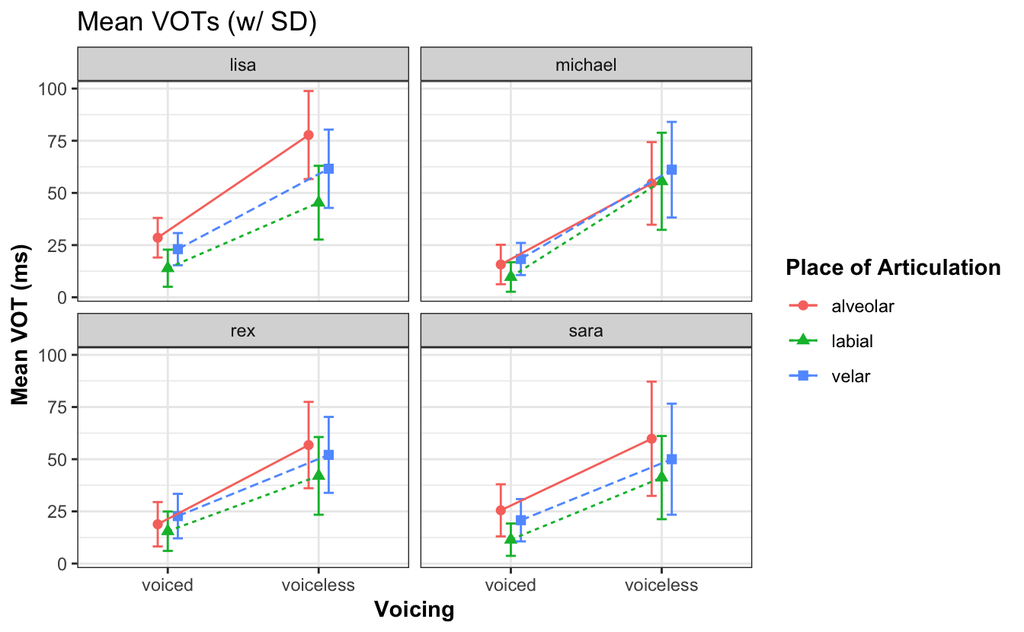

Figure 1: Reproduce this plot.

Interpret your plots. Describe the differences between speakers, voicing, and of place of articulation (and if any of these differences varied as a function of another variable, e.g., are the differences of voicing and place of articulation the same for all speakers?).

# Reflection

Reflect on your journey through this course. What did you find particularly interesting? What was difficult? What do you still struggle with? Do you see yourself applying what you’ve learned in future work?

## References

Sonderegger, M. (2023). *Regression Modeling for Linguistic Data*.

Sonderegger, M., Bane, M., & Graff, P. (2017). The medium-term dynamics of accents on reality television. *Language*, *93*(3), 598–640. https://doi.org/10.1353/lan.2017.0038